# Bootcamp Modeling Exercises

Regina Zweng

9/27/2017

In class we saw how to simulate discrete-time models (such as the discrete logistic growth model) in R, using a for loop. Now we will work with an alternative model for density-dependent population growth in discrete time, the Ricker model where K > 0 and r can take positive or negative values.

1. Write a function that runs the Ricker model, plots the result, and returns the time series as an output. At minimum, your function should take all parameter values and initial conditions as input arguments.

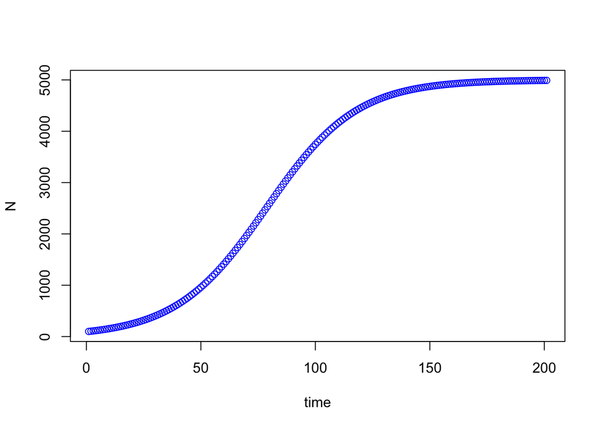

```r
#1. Setup
#None needed, since the program is so simple

#2. Set initial conditions and parameter values
N0<-100
RR<-0.05
KK<-5000
ttMax<-200
#initialize variables to a vector of NA values
NN<-matrix(NA,nrow=1,ncol=ttMax+1)
NN[1]<-N0 #set first value to initial conditions

#3 Perform Calculations
#use a loop to iterate the model the desired number of times
for (tt in 1:ttMax){
  NN[tt+1]<-NN[tt]*exp(RR*(1-(NN[tt]/KK)))}

#4 Plot the results
plot(1:(ttMax+1),NN,xlab="time", ylab="N", col="blue"
     )
```

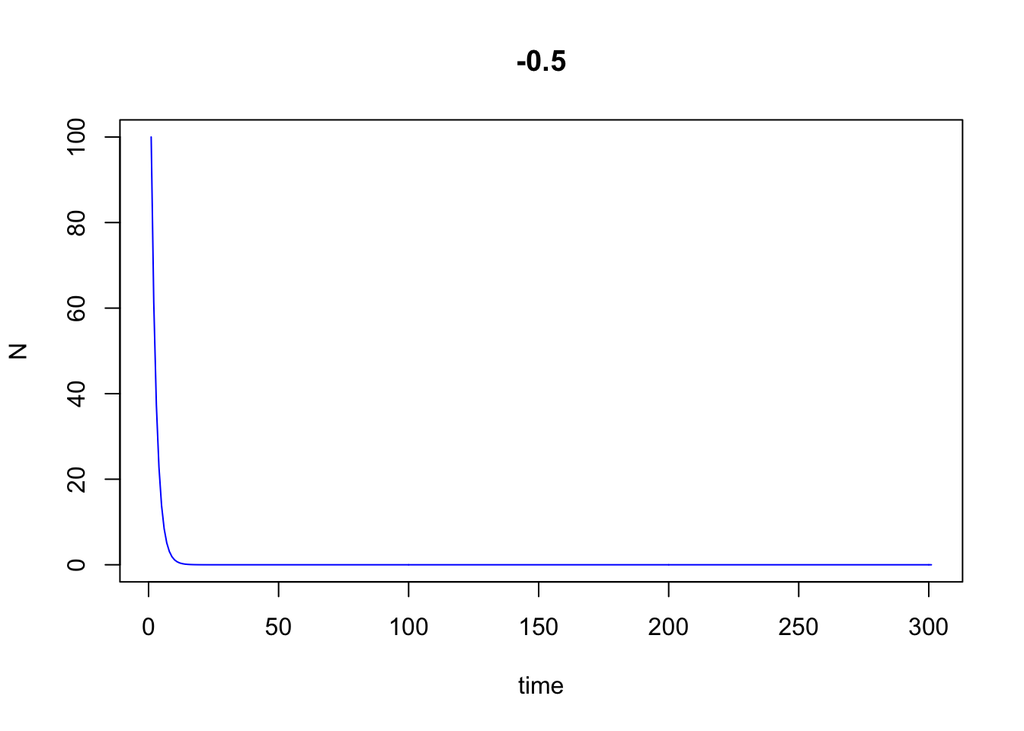

```r
#5 Write as a function
RickerFun<-function(RR,N0,KK,ttMax,PLOTFLAG=1,output=1){

  #initialize variables to a vector of NA values
  NN<-matrix(NA,nrow=1,ncol=ttMax+1)
  NN[1]<-N0 #set first value to initial conditions
  for (tt in 1:ttMax){
    NN[tt+1]<-NN[tt]*exp(RR*(1-(NN[tt]/KK)))}

  if (PLOTFLAG==0){
  plot(1:(ttMax+1),NN,xlab="time", ylab="N", col="blue",type='l',main=RR
  )}
  if(output==1)
  {return(NN)}
  }

#Example
RickerFun(-0.5,100,5000,300,PLOTFLAG=0,output=0)
```

2. Explore the dynamics of the model. Try to find combinations of parameter values that yield the following patterns: • Population decreases to n = 0. • Population approaches stable equilibrium at n ∗ = K, without oscillations. • Decaying oscillations around n ∗ = K. • Persistent, regular oscillations. • Crazy, random-looking fluctuations (chaos). Which parameter is the key driver of these patterns?

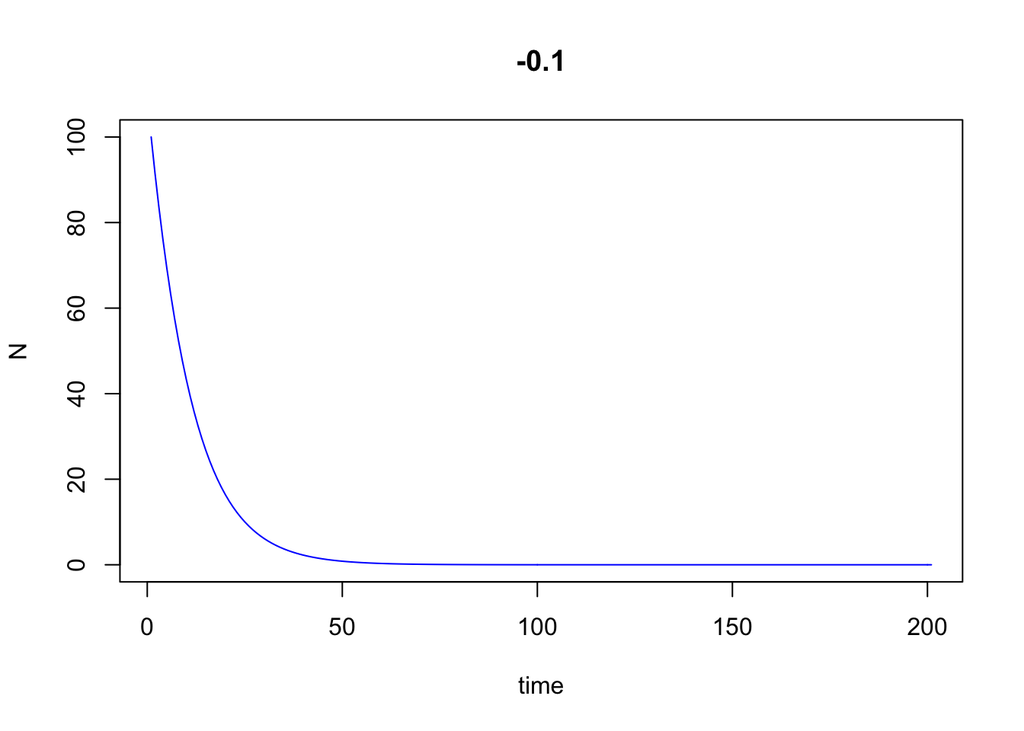

```r
#Population decreases to n=0. Must have a negative RR
RickerFun(-0.1,100,1000,200,PLOTFLAG=0,output=0)
```

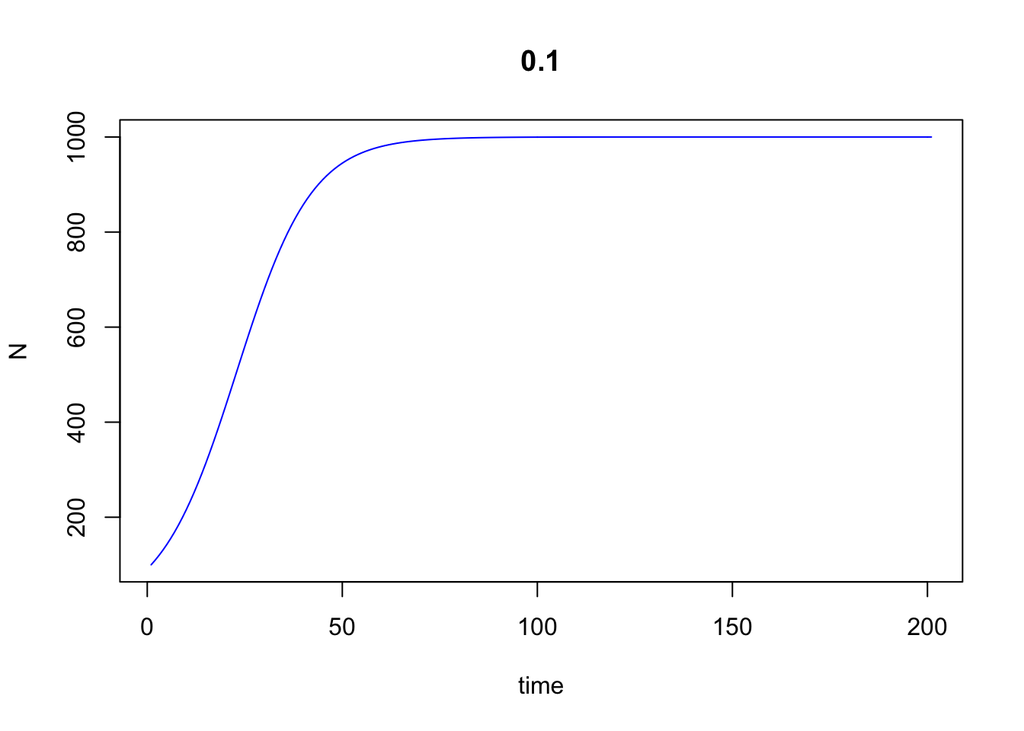

```r
#Population approaches stable equilibrium at n∗ = K, without oscillations. Must have a positive RR.
RickerFun(0.1,100,1000,200,PLOTFLAG=0,output=0)
```

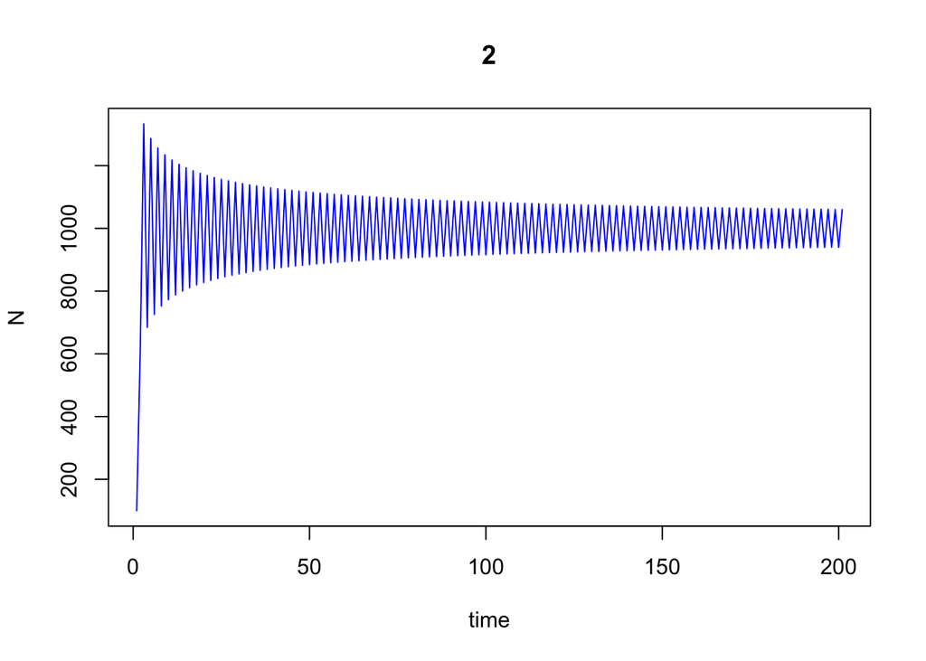

```r
#Decaying oscillations around n∗ = K.
RickerFun(2,100,1000,200,PLOTFLAG=0,output=0)
```

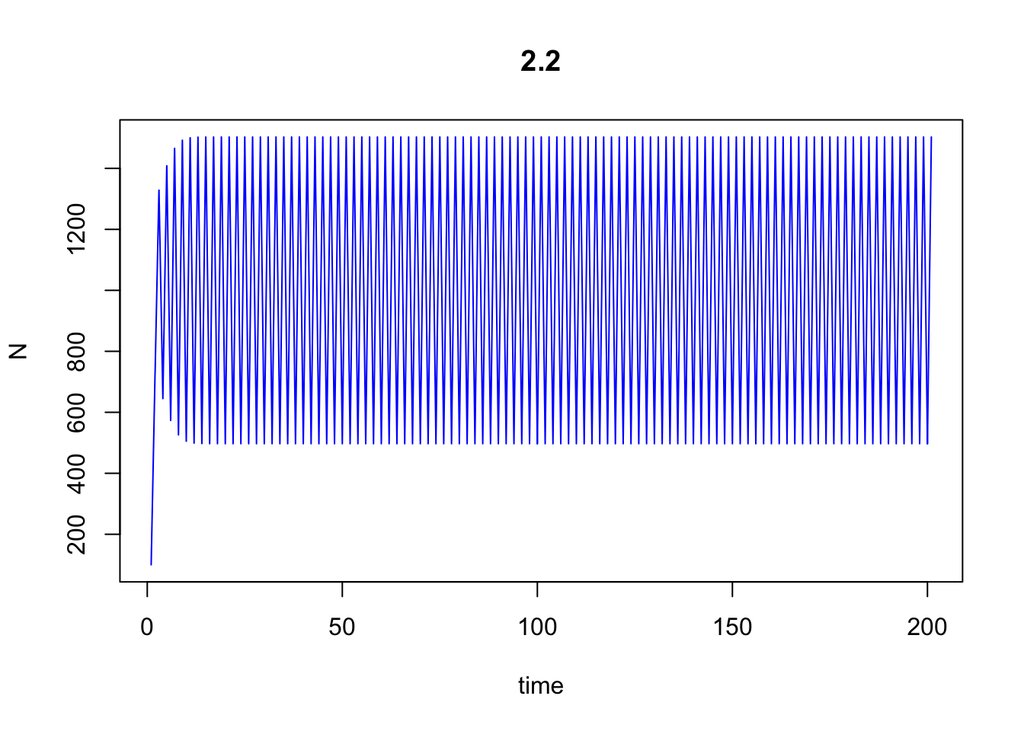

```r
#Persistent, regular oscillations.
RickerFun(2.2,100,1000,200,PLOTFLAG=0,output=0)
```

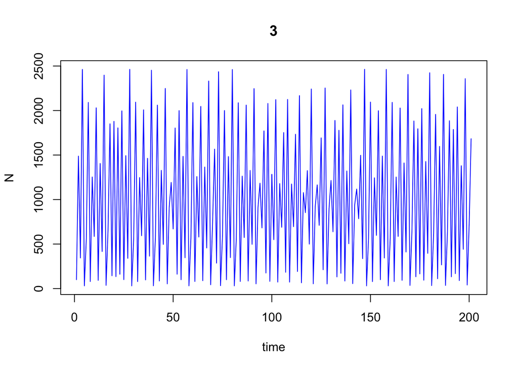

```r
# Crazy, random-looking fluctuations (chaos).
RickerFun(3,100,1000,200,PLOTFLAG=0,output=0)
```

```r
#The Key parameter to change is RR (r)
```

3. Choose six interesting values of this parameter. Write a script that makes an array of six plots showing the model dynamics for each of these values.

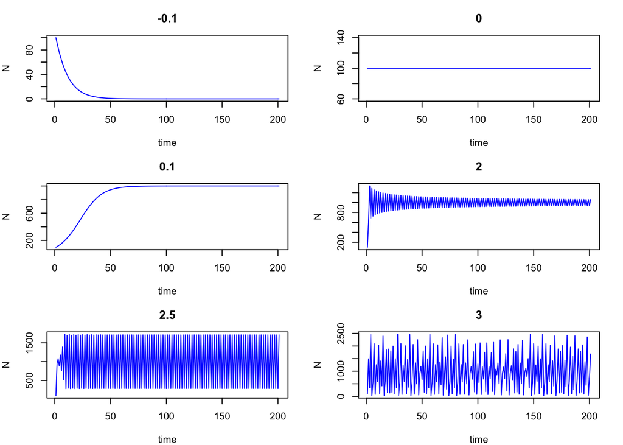

```r
# Define parameter values; use a vector to hold a range of values for the parameter(s) you wish to vary.
growthRate<-c(-0.1,0,0.1,2,2.5,3)

par(mfrow=c(3,2),mar=c(4,4,3,2))
for (ii in 1:length(growthRate)){
  RickerOutput<-RickerFun(RR=growthRate[ii],100,1000,200,PLOTFLAG=0,output=0)
}
```

4. Imagine n0 = 20 and K = 1000 for a certain population of deer that is growing according to the Ricker model. You are a wildlife manager, and are concerned about how long it will take for the population to reach half of its carrying capacity. That is, you want to know tK/2 , the first year that nt ≥ K/2. Suppose your output time series is called nVec. Write an R command that will determine the index of the first element of nVec that is ≥ K/2.

```r
N0<-20
KK<-1000
RR<-1.05
tt<-seq(1,100,by=1)
nVec<-rep(NA,length(tt))
for (ii in 1:length(tt)){nVec<-RickerFun(RR,N0,KK,tt[ii])}

which(nVec>=500)[1]
```

```
## [1] 5
```

5. Write a script that runs the necessary simulations and collects the necessary data to plot how tK/2 depends on r, for the range of r from 0.1 to 0.9.

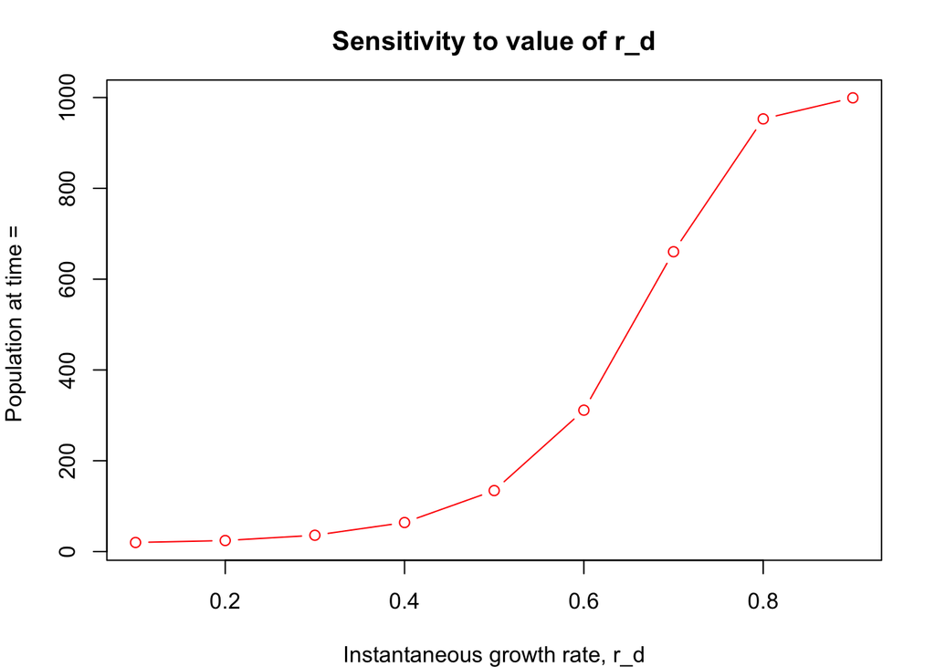

```r
#initialize parameters
rrVec<-seq(0.1,0.9,by=0.1)
N0<-20
KK<-1000
tt<-50

# initialize vector with null values
nnVec <- rep(NA, 1, length(rrVec))

# loop over values of key parameter, and run model for each value
for (ii in 1:length(rrVec)) {
  RickerOutput <- RickerFun(N0, RR=rrVec[ii], KK,
  tt)
  nnVec[ii] <- RickerOutput[ii]
}
# plot the results
par(mfrow=c(1,1),mar=c(4,4,3,2))
plot(rrVec, nnVec, xlab='Instantaneous growth rate, r_d',
ylab=paste('Population at time = '),
type='b', col='red', main='Sensitivity to value of r_d')
```

6. Write pseudo-code to do a joint sensitivity analysis for two parameters. That is, choose a vector of values you’d like to consider for both r and K, and choose a simple output from your model (e.g. population size at t = 10). Run the model for all possible combinaioins of these values and collect the results in a matrix with appropriate dimensions. Plot the results in some way. Hint: the straight-forward way to do this uses a ‘nested loop’.

```r
#Initialize variables

# initialize matrix with null values for storage of results

# loop over values of key parameters in a nested "for" loop that stores results in matrix

# plot the results with a 3D contour or perspective plot
```

7. Convert your pseudo-code into an R script to do a two-dimensional sensitivity analysis, and create a visually appealing plot to summarize the results. (You will need to google for plotting commands, e.g. contour or surface plots).

```r
#Initialize variables
rrVec<-seq(0.1,1.0,by=0.1)
N0<-20
KK<-seq(100,1000,by=100)
tt<-30

# initialize matrix to store d with null values
NN<-matrix(NA,nrow=length(rrVec),ncol=length(KK))

# loop over values of key parameter, and run model for each value
for (ii in 1:length(rrVec)) {
  for (jj in 1:length(KK))
  RickerOutput<-RickerFun(N0, RR=rrVec[ii], 100,
  tt)
  NN[ii]<-RickerOutput[ii]
  }

for (ii in 1:length(rrVec)) {
  for (jj in 1:length(KK))
  RickerOutput<-RickerFun(N0, RR=rrVec[ii], 200,
  tt)
  NN[ii,2]<-RickerOutput[ii]
  }

for (ii in 1:length(rrVec)) {
  for (jj in 1:length(KK))
  RickerOutput<-RickerFun(N0, RR=rrVec[ii], 300,
  tt)
  NN[ii,3]<-RickerOutput[ii]
  }

for (ii in 1:length(rrVec)) {
  for (jj in 1:length(KK))
  RickerOutput<-RickerFun(N0, RR=rrVec[ii], 400,
  tt)
  NN[ii,4]<-RickerOutput[ii]
  }

for (ii in 1:length(rrVec)) {
  for (jj in 1:length(KK))
  RickerOutput<-RickerFun(N0, RR=rrVec[ii], 500,
  tt)
  NN[ii,5]<-RickerOutput[ii]
  }

for (ii in 1:length(rrVec)) {
  for (jj in 1:length(KK))
  RickerOutput<-RickerFun(N0, RR=rrVec[ii], 600,
  tt)
  NN[ii,6]<-RickerOutput[ii]
  }

for (ii in 1:length(rrVec)) {
  for (jj in 1:length(KK))
  RickerOutput<-RickerFun(N0, RR=rrVec[ii], 700,
  tt)
  NN[ii,7]<-RickerOutput[ii]
  }

for (ii in 1:length(rrVec)) {
  for (jj in 1:length(KK))
  RickerOutput<-RickerFun(N0, RR=rrVec[ii], 800,
  tt)
  NN[ii,8]<-RickerOutput[ii]
  }

for (ii in 1:length(rrVec)) {
  for (jj in 1:length(KK))
  RickerOutput<-RickerFun(N0, RR=rrVec[ii], 900,
  tt)
  NN[ii,9]<-RickerOutput[ii]
  }

for (ii in 1:length(rrVec)) {
  for (jj in 1:length(KK))
  RickerOutput<-RickerFun(N0, RR=rrVec[ii], 1000,
  tt)
  NN[ii,10]<-RickerOutput[ii]
  }

RickerOutput
```

```
##      [,1]     [,2]     [,3]     [,4]     [,5]     [,6]     [,7]     [,8]
## [1,]   20 53.28912 137.3377 325.4163 638.8624 916.7426 996.3356 999.9933
##      [,9] [,10] [,11] [,12] [,13] [,14] [,15] [,16] [,17] [,18] [,19]
## [1,] 1000  1000  1000  1000  1000  1000  1000  1000  1000  1000  1000
##      [,20] [,21] [,22] [,23] [,24] [,25] [,26] [,27] [,28] [,29] [,30]
## [1,]  1000  1000  1000  1000  1000  1000  1000  1000  1000  1000  1000
##      [,31]
## [1,]  1000
```

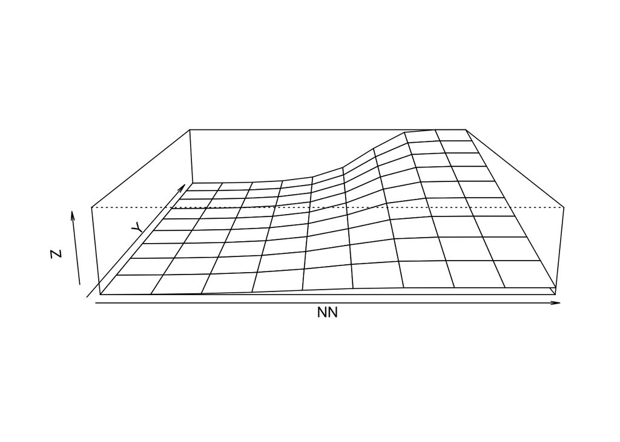

```r
# plot the results with a 3D contour or perspective plot
persp(NN, expand=0.2)
```